# Features under consideration

## Kikuchi line drawing

I’m considering implementing Kikuchi line drawing for my studies at https://github.com/SaitouToshihide/rgl.cry/tree/DiffractionCone.

```r
dp_demo(system.file("cubic_i.cif", package = "rgl.cry"), zoom = 0.03, res = 1.3)
##rgl::snapshot3d("cubic_i_01.png", fmt="png", width=500, height=500, webshot = FALSE)
dp_demo(system.file("cubic_i.cif", package = "rgl.cry"), zoom = 0.0005, res = 1.3)
##rgl::snapshot3d("cubic_i_02.png", fmt="png", width=500, height=500, webshot = FALSE)
```

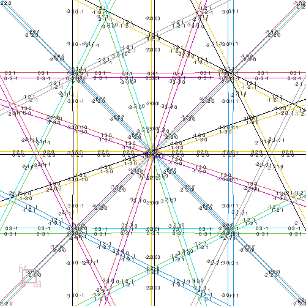

Kikuchi lines of BCC structure along the [0 0 1] axis.

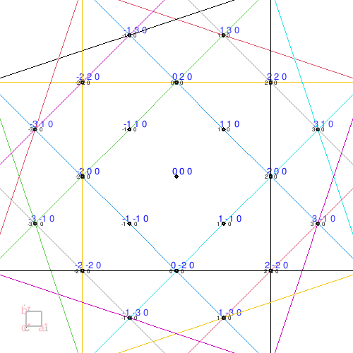

A zoomed-in view.

Images while debugging.

#### Installation

```r
library(devtools)

install_github("SaitouToshihide/rgl.cry", ref="5e63cad")
```

#### Usage.

Run `dp_demo()`.

```r
dp_demo() # default CIF data are loaded.
```

Let’s see another crystal system.

```r
dp_demo(system.file("triclinic_p.cif", package = "rgl.cry"), zoom = 0.03, res = 2.0)
##rgl::snapshot3d("triclinic_p_001_01.png", fmt="png", width=500, height=500, webshot = FALSE)
dp_demo(system.file("triclinic_p.cif", package = "rgl.cry"), zoom = 0.0003, res = 2.0)
##rgl::snapshot3d("triclinic_p_001_02.png", fmt="png", width=500, height=500, webshot = FALSE)
```

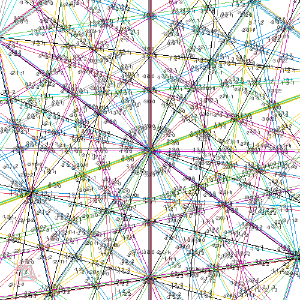

triclinic_p_001_01.png

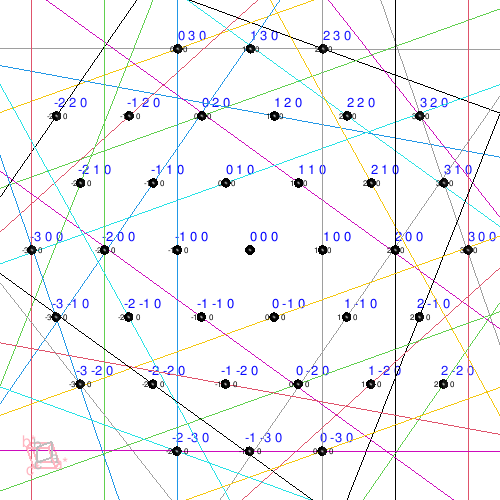

triclinic_p_001_02.png

Triclinic crystal.

In this case, even in a triclinic lattice, diffraction spots such as (1 1 0) are visible. This is because the corresponding [1 1 0] vector in reciprocal space remains parallel to the xy-plane, even if the real-space [1 1 0] vector is inclined relative to the xy-plane. We should not focus on imaging the vector denoted by Miller indices in real space. Instead, we should consider the repetition of planes and their normal direction or alternatively, image a vector in reciprocal space denoted by Miller indices. Let’s see.

```r
cry_demo()
align("90 0")
align("0 50") #

library(pryr)

lCIF <- rgl.cry:::pkg$inst[[nrow(rgl.cry:::pkg$inst), "lCIF"]]
a <- lCIF$HEADER$CELL$A$VAL
b <- lCIF$HEADER$CELL$B$VAL
c <- lCIF$HEADER$CELL$C$VAL
aa <- lCIF$HEADER$CELL$ALPHA$VAL # degree
bb <- lCIF$HEADER$CELL$BETA$VAL
cc <- lCIF$HEADER$CELL$GAMMA$VAL
mat02 <- cry::xtal_mat02(a, b, c, aa, bb, cc)

vertices <- rbind(c(1,0,0), c(1,0,1), c(0,1,1), c(0,1,0))
vertices <- t(apply(vertices, 1, function(v) v %*% mat02))
combinations <- c(1,2,3,1, 1,4,3,1)
rgl::shade3d(rgl::mesh3d(vertices, quads = combinations), col = "blue", alpha = 0.9)

vertices <- rbind(c(1,0,0), c(1,0,1), c(0,1,1), c(0,1,0))
vertices <- t(apply(vertices, 1, function(v) v + c(1, 1, 0)))
vertices <- t(apply(vertices, 1, function(v) v %*% mat02))
rgl::shade3d(rgl::mesh3d(vertices, quads = combinations), col = "green", alpha = 0.9)
##rgl::snapshot3d("triclinic_p.png", fmt="png", width=500, height=500, webshot = FALSE)
```

This is the side view of the image looking down along with c-axis indicated above as dp pattern. We can observe that the direction [1 1 0] inclined in real space. However, as the repetition of planes, this lies parallel to the xy-plane.

IMPORTANT: Adding 3D graphics objects is made easy and flexible within R using the rgl and cry packages.

[interactive chart not shown]

Let’s check this numerically.

```r
> mat02 <- cry::xtal_mat02(a, b, c, aa, bb, cc)
> ea1 <- as.numeric(c(1, 0, 0) %*% mat02)
> ea2 <- as.numeric(c(0, 1, 0) %*% mat02)
> ea3 <- as.numeric(c(0, 0, 1) %*% mat02)

> library(pracma)
> V <- as.numeric(ea1 %*% cross(ea2, ea3))
> eb1 <- cross(ea2, ea3) / V
> eb2 <- cross(ea3, ea1) / V
> eb3 <- cross(ea1, ea2) / V

## The [1 1 0] vector in real space and its corresponding coordinates in the Cartesian system.
> 1*ea1 + 1*ea2 + 0*ea3
[1] 6.554986 9.455095 5.356230

## The [1 1 0] vector in reciprocal space and its corresponding coordinates in the Cartesian system.
> 1*eb1 + 1*eb2 + 0*eb3
[1] 0.1020649 0.1407670 0.0000000
```

In reciprocal space, the vector denoted by Miller indices is perpendicular to the plane in real space with the same Miller indices.

You may be confused if you are asked to calculate the interplanar spacing in a triclinic lattice. Don’t worry, it’s easy when using reciprocal lattice vectors.

```r
## The interplanar spacing of the (1 1 0) planes in this crystal is 1/0.1738753 Å.
> hkl[which(hkl$H=="1" & hkl$K=="1" & hkl$L=="0"),]
     H K L         S
 124 1 1 0 0.1738753

> 1 / 0.1738753
[1] 5.751248

> n110b <- (1*eb1 + 1*eb2 + 0*eb3)
> norm(n110b, "2")
[1] 0.1738753


## On the other hand,
> n110a <- (1*ea1 + 1*ea2 + 0*ea3) * c(1, 1, 0)
> norm(n110a, "2")
[1] 11.50507

> norm(n110a, "2") / 2
[1] 5.752536

## Although the calculated value may initially appear plausible after being halved,
## this approach, using the lattice vector of real space, is fundamentally flawed and unproductive.
```

## Hough transformation

Prepare image.

```r
library(rgl.cry)

dp_demo(system.file("cubic_i.cif", package = "rgl.cry"), zoom = 0.03, res = 1.3)
## Remove spot, label, etc.
rgl::pop3d(tag = c("rlpoints0", "rlpoints1", "rlpoints2"))
objIds <- rgl::ids3d(tag = TRUE, subscene = 0)
objIds <- objIds[grep("^rlpoints[4-5].*", objIds$tag), ]
rgl::pop3d(id = objIds$id)
## remove manually in this way
rgl::ids3d(subscene = 0)
##rgl::pop3d(id = 16)
rgl::par3d(zoom = 0.4)
## Save the image.
rgl::snapshot3d("cubic_i_03.png", fmt="png", width=500, height=500, webshot = FALSE)
```

Utilize ImageMagick to blur, grayscale conversion, and inversion to achieve a visual representation that resembles the original observed image. ((In this case, procedures based on theory can be considered, but in general image applications, what methods are there for converting basic features into actual images, and what would happen if they were applied? Applying image blur can be motivated by our visual perception or by limitations inherent in the observation process, making it a common image effect.))

```r
  % convert -blur 10x10 cubic_i_03.png -colorspace Gray -negate cubic_i_03bw.png
```

You can also use the magick package.

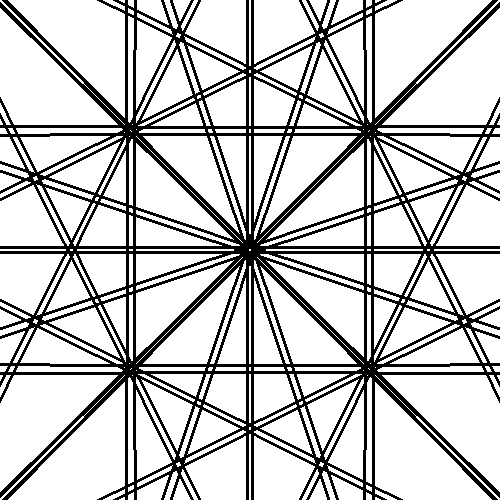

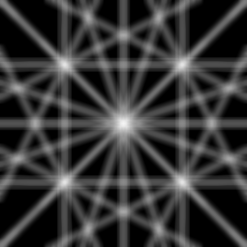

Converted image cubic_i_03bw.png.

```r
library(magick)

img <- image_read("cubic_i_03.png")
img <- image_blur(img, 10, 10)
img <- image_convert(img, type = 'grayscale')
img <- image_negate(img)
image_browse(img)
image_write(img, path = "cubic_i_03bw.png", format = "png")
```

The original image and the image after applying the effect.

Reconstruct the line from Hough transform data and overlay it onto the original image.

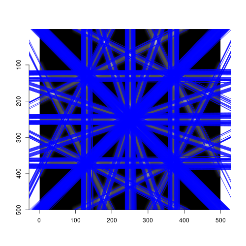

```r
library(imager)

file <- "cubic_i_03bw.png"
im <- load.image(file)
plot(im)
hough_line(im, ntheta=500) %>% plot # Very hard to see
df <- hough_line(im, ntheta=500, data.frame=TRUE)
df <- subset(df, score > quantile(score, .9991))
df <- df[which(df$score != 0),]
##png(filename="cubic_i_03ovl.png", width=500, height=500, units="px")
plot(im)
nfline(df$theta, df$rho, col="blue")
##dev.off()
```

The original image with lines detected using the Hough transform overlaid.

To improve the visual representation of Hough transform data, I used the following settings:

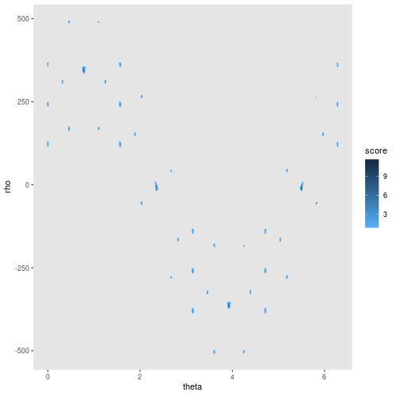

```r
library(ggplot2)

##png(filename="cubic_i_03ht.png", width=500, height=500, units="px")
ggplot(data = df) +
  geom_point(aes(x = theta, y = rho, color = score), size = 0.1) +
  scale_color_gradient(low = "#56B1F7", high = "#132B43") +
  theme(panel.background = element_rect(fill = "gray90"),
      panel.grid.major = element_blank(),
      panel.grid.minor = element_blank(),
      plot.background = element_rect(fill = "white"))
##dev.off()
```

cubic_i_03ht.png.

We detect lines in the image using Hough transform and keep only the highest-scoring 1-0.9991 %. Let’s check this.

```r
> plot(im)
> nfline(df$theta, df$rho, col="blue")

## To plot the detected line, substitute the values of theta and rho obtained
## from the Hough transform into the equation cos(theta)*x + sin(theta)*y = rho.
## This can be done using nfline. Let's check it out.

> df[which(df$score == max(df$score)), ]
          theta      rho    score
442140 3.928565 -362.169 11.64875
>
## y = (rho - cos(theta)*x)/sin(theta)
## y = (rho - cos(3.928565)*x)/sin(3.928565)

> f1 <- function(x){ (-362.169 + 0.7059928*x) / -0.708219 }
> par(new=T)
> plot(f1, n=1000, col="red", xaxt="n", yaxt="n", xlab="", ylab="")
```

Utilize the pracma package for peak detection.

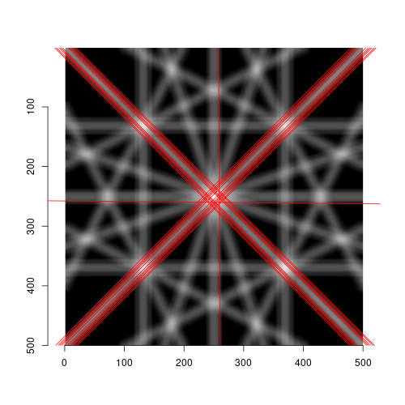

cubic_i_04ovl.png.

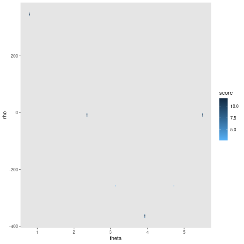

cubic_i_04ht.png.

```r
library(pracma)

im <- load.image(file)

df <- hough_line(im, ntheta=500, data.frame=TRUE)

## Treating a vertical raster column (rho) as a one-dimensional data.
## Then find peaks using findpeaks (adjust minpeakheight and threshold as needed).
data_vector_rho <- df$score
peak_indices_rho <- findpeaks(data_vector_rho, minpeakheight = 2.5, threshold = 0.5)
df4 <- df[peak_indices_rho[,2],]

##png(filename="cubic_i_04ovl.png", width=500, height=500, units="px")
plot(im, xaxs = "i", yaxs = "i")
nfline(df4$theta, df4$rho, col="red")
##dev.off()

##png(filename="cubic_i_04ht.png", width=500, height=500, units="px")
ggplot(data = df4) +
  geom_point(aes(x = theta, y = rho, color = score), size = 0.1) +
  scale_color_gradient(low = "#56B1F7", high = "#132B43") +
  theme(panel.background = element_rect(fill = "gray90"),
      panel.grid.major = element_blank(),
      panel.grid.minor = element_blank(),
      plot.background = element_rect(fill = "white"))
##dev.off()
```

The major peak selection and its result.

And this does not lead to further improvement:

```r
## Treating a horizontal raster row (theta).
data_vector_theta <- df[order(df[, "rho"], df[, "theta"]), "score"]
peak_indices_theta <- findpeaks(data_vector_rho, minpeakheight = 2.5, threshold = 0.5)
nrho <- nrow(df[which(df$theta == 0),])
row_coords <- ceiling(peak_indices_theta[,2] / nrho)
col_coords <- peak_indices_theta[,2] %% nrho
df5 <- df[nrho * row_coords + col_coords,]
## Or even further, multiply by the vertical result?
```